# IODS course project

Elina Sohlberg

# Introduction to Open Data Science - Course Project

# About the project

*Write a short description about the course and add a link to your GitHub repository here. This is an R Markdown (.Rmd) file so you should use R Markdown syntax.*

This is my course diary for the Open Data Science course 2022.

Link to my GitHub repository: https://github.com/emselina/IODS-project.git

```r
# This is a so-called "R chunk" where you can write R code.

date()
```

```
## [1] "Mon Nov 21 18:36:26 2022"
```

# Assignment 1.

Link to my GitHub repository: [Elina GitHub IODS](https://github.com/emselina/IODS-project.git)

https://github.com/emselina/IODS-project.git

*Just write some of your thoughts about this course freely in the file, e.g., How are you feeling right now? What do you expect to learn? Where did you hear about the course?*

I feel curious about the course and interested to learn new things. I expect to learn more about R and RStudio. **GitHub** I have never used before so that I would like to learn to deposit my own R codes in the future. I would like to learn the core themes of open data science and how to use them in my own research.

*Also reflect on your learning experiences with the R for Health Data Science book and the Exercise Set 1: How did it work as a “crash course” on modern R tools and using RStudio? Which were your favorite topics? Which topics were most difficult? Some other comments on the book and our new approach of getting started with R Markdown etc.?*

I think the Health Data Science book contained a lot of useful information about R and RStudio and also good examples.

My favorite topic in the book was the different types of plots section and also the R basics. I have not used the pipe function %>% before so that was useful information. The most difficult parts I believe will be the data analysis part: linear regression, logistic regression etc. that I have not done before.

I also created a Personal Access Token (PAT) but everything worked before creating it as well.

# Assignment 2

*Describe the work you have done this week and summarize your learning.*

- Describe your work and results clearly.
- Assume the reader has an introductory course level understanding of writing and reading R code as well as statistical methods.
- Assume the reader has no previous knowledge of your data or the more advanced methods you are using.

```r
date()
```

```
## [1] "Mon Nov 21 18:36:26 2022"
```

Here we go again…

## Data wrangling

The data wrangling part and the R scipt created are in the data folder in: https://github.com/emselina/IODS-project/blob/master/data/create_learning2014.R

## Data analysis

*1. Read the students2014 data into R either from your local folder (if you completed the Data wrangling part) or from this url: https://raw.githubusercontent.com/KimmoVehkalahti/Helsinki-Open-Data-Science/master/datasets/learning2014.txt . (The separator is a comma “,” and the file includes a header). Explore the structure and the dimensions of the data and describe the dataset briefly, assuming the reader has no previous knowledge of it. There is information related to the data here. (0-2 points)*

I did the data wrangling part so I will use the data that I created:

```r
#students14 <- read.table("https://raw.githubusercontent.com/KimmoVehkalahti/Helsinki-Open-Data-Science/master/datasets/learning2014.txt", sep=",", header=TRUE)

students14 <- read.csv("data/learning2014.csv", sep=",", header=TRUE)
```

```r
dim(students14)
```

```
## [1] 166   7
```

```r
str(students14)
```

```
## 'data.frame':    166 obs. of  7 variables:
##  $ gender  : chr  "F" "M" "F" "M" ...
##  $ Age     : int  53 55 49 53 49 38 50 37 37 42 ...
##  $ attitude: num  3.7 3.1 2.5 3.5 3.7 3.8 3.5 2.9 3.8 2.1 ...
##  $ deep    : num  3.58 2.92 3.5 3.5 3.67 ...
##  $ stra    : num  3.38 2.75 3.62 3.12 3.62 ...
##  $ surf    : num  2.58 3.17 2.25 2.25 2.83 ...
##  $ points  : int  25 12 24 10 22 21 21 31 24 26 ...
```

This students2014 dataset has 166 rows and 7 columns. So this dataset has 166 observations and we excluded those who have obtained 0 for Exam Points. This dataset is from international survey of Approaches to Learning. In the survey basic details about age and gender were asked and questions were divided to deep questions (deep), strategic questions (stra), surface questions (surf). In addition points from the exam of the course is reported in the dataset and global attitude towards statistics. Attitude and the questions are measured on the Likert scale (1-5). So there is 7 variables is this dataset: `gender`,`Age`, `Attitude`, `deep`, `stra`, `surf` and `Points`.The attitude variable was created in the data wrangling part by dividing by 10 the original attitude data to get it to the same scale as others. The deep, stra and surf were created by taken the mean values of each type of questions.

*2. Show a graphical overview of the data and show summaries of the variables in the data. Describe and interpret the outputs, commenting on the distributions of the variables and the relationships between them. (0-3 points)*

```r
summary (students14)
```

```
##     gender               Age           attitude          deep
##  Length:166         Min.   :17.00   Min.   :1.400   Min.   :1.583
##  Class :character   1st Qu.:21.00   1st Qu.:2.600   1st Qu.:3.333
##  Mode  :character   Median :22.00   Median :3.200   Median :3.667
##                     Mean   :25.51   Mean   :3.143   Mean   :3.680
##                     3rd Qu.:27.00   3rd Qu.:3.700   3rd Qu.:4.083
##                     Max.   :55.00   Max.   :5.000   Max.   :4.917
##       stra            surf           points
##  Min.   :1.250   Min.   :1.583   Min.   : 7.00
##  1st Qu.:2.625   1st Qu.:2.417   1st Qu.:19.00
##  Median :3.188   Median :2.833   Median :23.00
##  Mean   :3.121   Mean   :2.787   Mean   :22.72
##  3rd Qu.:3.625   3rd Qu.:3.167   3rd Qu.:27.75
##  Max.   :5.000   Max.   :4.333   Max.   :33.00
```

```r
# access the GGally and ggplot2 libraries
library(GGally)
library(ggplot2)
```

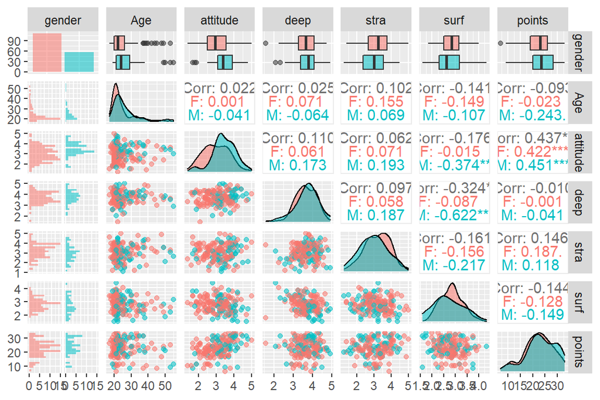

```r
p <- ggpairs(students14, mapping = aes(col = gender, alpha = 0.3), lower = list(combo = wrap("facethist", bins = 20)))
p
```

The variable gender is categorical variable so it can not be used in the statistical tests as a variable.

From the graphigal overview is can be see that the variable `Age` is a positively skewed distribution, variable `attitude` shows almost like normal distribution but some differences are between genders, the females are skewed to the right and males skewed to the left. The variable `deep` shows negatively skewed distribution and distribution of `surf` slightly positively skewed distribution.

There is statistically significant positive correlation between `points` and `attitude` in both females and males. The variable with the second highest absolute correlation with `Points` is `stra` and third highest absolute correlation with `Points` is `surf`

There is also negative correlation between `surf` and `deep` (figure below), but only significant correlation is in the male participants. There is also negative correlation between `surf` and `attitude` and surf and `stra`.

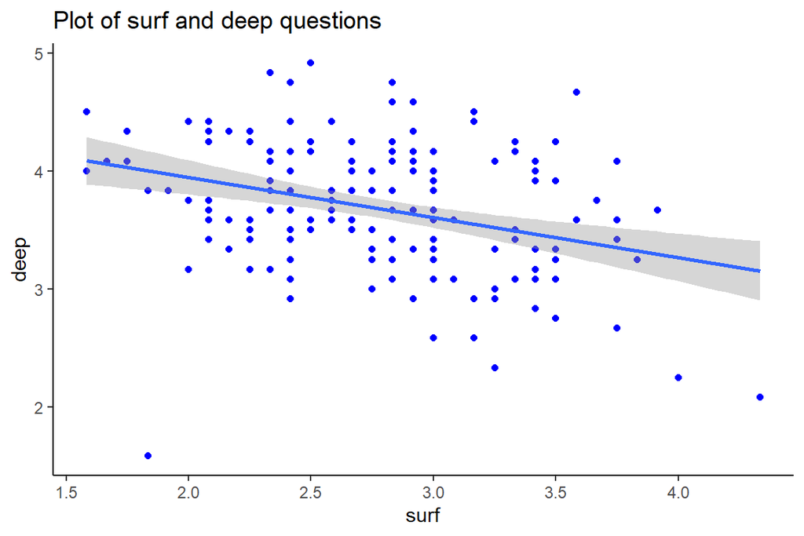

```r
surf_deep <- ggplot(students14, aes(x = surf, y = deep)) +
  labs(title="Plot of surf and deep questions",x="surf", y = "deep")
surf_deep <- surf_deep + geom_point(colour = "blue") + theme_classic() + geom_smooth(method = "lm")
surf_deep
```

*3. Choose three variables as explanatory variables and fit a regression model where exam points is the target (dependent, outcome) variable. Show a summary of the fitted model and comment and interpret the results. Explain and interpret the statistical test related to the model parameters. If an explanatory variable in your model does not have a statistically significant relationship with the target variable, remove the variable from the model and fit the model again without it. (0-4 points)*

*Multiple regression*

```r
# create a regression model with multiple explanatory variables
my_model <- lm(points ~ attitude + surf + stra, data = students14)

my_model %>%
  summary()
```

```
##
## Call:
## lm(formula = points ~ attitude + surf + stra, data = students14)
##
## Residuals:
##      Min       1Q   Median       3Q      Max
## -17.1550  -3.4346   0.5156   3.6401  10.8952
##
## Coefficients:
##             Estimate Std. Error t value Pr(>|t|)
## (Intercept)  11.0171     3.6837   2.991  0.00322 **
## attitude      3.3952     0.5741   5.913 1.93e-08 ***
## surf         -0.5861     0.8014  -0.731  0.46563
## stra          0.8531     0.5416   1.575  0.11716
## ---
## Signif. codes:  0 '***' 0.001 '**' 0.01 '*' 0.05 '.' 0.1 ' ' 1
##
## Residual standard error: 5.296 on 162 degrees of freedom
## Multiple R-squared:  0.2074, Adjusted R-squared:  0.1927
## F-statistic: 14.13 on 3 and 162 DF,  p-value: 3.156e-08
```

The Residuals:

A residual is a measure of how far away a point is vertically from the regression line. Simply, it is the error between a predicted value and the observed actual value. In this case the median residuals is 0.5156 so it is quite close to 0, it is positive because residuals are above the regression line.

Std.Error: shows the standard deviation of the coefficient. The standard error is used to create confidence intervals.

To conclude the only explanatory variable that has significant relationship with the target variable `points` is `attitude` so I decided to drop the other two explanatory variables `surf` and `stra`. This is based on the Pr(>|t|) values and for `surf` and `stra` these values are above 0.1 so these have no significant correlation with `points`. The Pr(>|t|) value of `attitude` is 1.93e-08 *** so there is significant positive correlation with `points`.

*Fit the model without explanatory variables that do not have a statistically significant relationship with the target variable.*

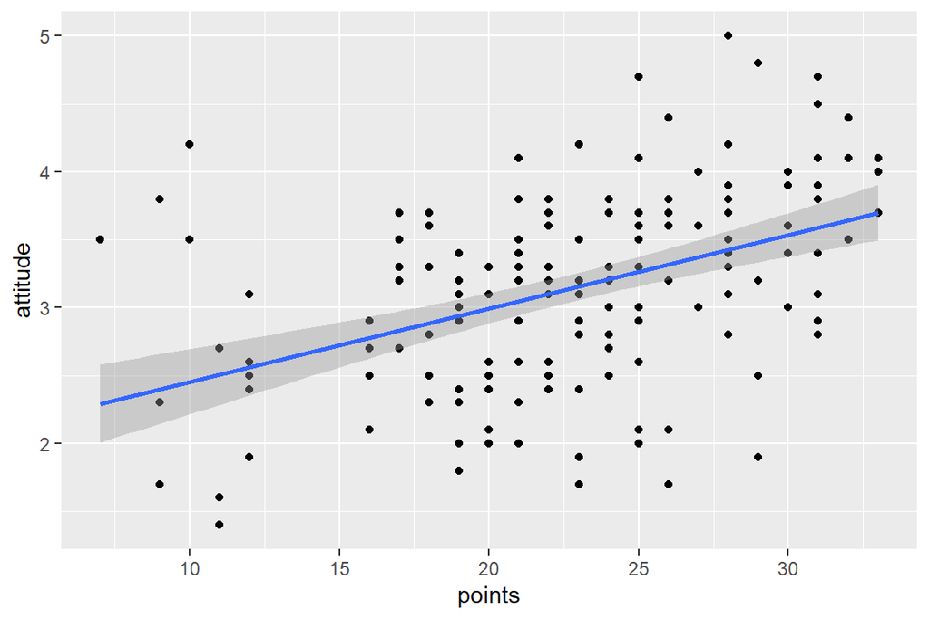

```r
library(GGally)
library(ggplot2)

library(ggplot2)
qplot(points, attitude, data = students14) + geom_smooth(method = "lm")
```

```r
# create a regression model with only statistically significant explanatory variables
my_model2 <- lm(points ~ attitude, data = students14)

my_model2 %>%
  summary()
```

```
##
## Call:
## lm(formula = points ~ attitude, data = students14)
##
## Residuals:
##      Min       1Q   Median       3Q      Max
## -16.9763  -3.2119   0.4339   4.1534  10.6645
##
## Coefficients:
##             Estimate Std. Error t value Pr(>|t|)
## (Intercept)  11.6372     1.8303   6.358 1.95e-09 ***
## attitude      3.5255     0.5674   6.214 4.12e-09 ***
## ---
## Signif. codes:  0 '***' 0.001 '**' 0.01 '*' 0.05 '.' 0.1 ' ' 1
##
## Residual standard error: 5.32 on 164 degrees of freedom
## Multiple R-squared:  0.1906, Adjusted R-squared:  0.1856
## F-statistic: 38.61 on 1 and 164 DF,  p-value: 4.119e-09
```

*4. Using a summary of your fitted model, explain the relationship between the chosen explanatory variables and the target variable (interpret the model parameters). Explain and interpret the multiple R-squared of the model. (0-3 points)*

```r
my_model2 %>%
  summary()
```

```
##
## Call:
## lm(formula = points ~ attitude, data = students14)
##
## Residuals:
##      Min       1Q   Median       3Q      Max
## -16.9763  -3.2119   0.4339   4.1534  10.6645
##
## Coefficients:
##             Estimate Std. Error t value Pr(>|t|)
## (Intercept)  11.6372     1.8303   6.358 1.95e-09 ***
## attitude      3.5255     0.5674   6.214 4.12e-09 ***
## ---
## Signif. codes:  0 '***' 0.001 '**' 0.01 '*' 0.05 '.' 0.1 ' ' 1
##
## Residual standard error: 5.32 on 164 degrees of freedom
## Multiple R-squared:  0.1906, Adjusted R-squared:  0.1856
## F-statistic: 38.61 on 1 and 164 DF,  p-value: 4.119e-09
```

The linear regression coefficients describe the mathematical relationship between each independent variable and the dependent variable. The p values for the coefficients indicate whether these relationships are statistically significant.

The Residuals:

A residual is a measure of how far away a point is vertically from the regression line. Simply, it is the error between a predicted value and the observed actual value. In this case the median residuals is 0.4339 so it is quite close to 0, it is positive because residuals are above the regression line.

Coefficients:

Intercept: This means the average exam score is 11.6 when the attitude towards statistics learning is 0.

Std.Error: shows the standard deviation of the coefficient. The standard error is used to create confidence intervals.

t-value: according to the t-value we can reject the null hypothesis: the slope for attitude is not equal to zero.

Multiple R-squared: This is known as the coefficient of determination. It is the proportion of the variance in the response variable that can be explained by the explanatory variables. In this example, 19% of the variation in the exam scores can be explained by the attitude..

*5. Produce the following diagnostic plots: Residuals vs Fitted values, Normal QQ-plot and Residuals vs Leverage. Explain the assumptions of the model and interpret the validity of those assumptions based on the diagnostic plots. (0-3 points)*

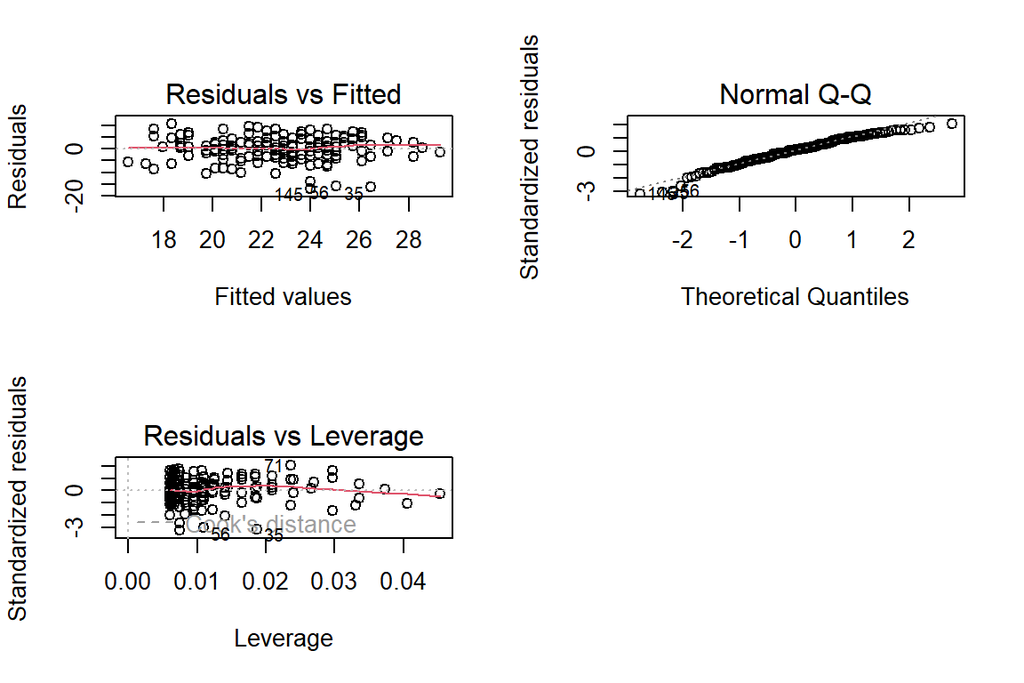

```r
par(mfrow = c(2,2))

plot(my_model2, c(1,2,5))
```

Residuals vs Fitted: The plot is used to detect non-linearity, unequal error variances, and outliers.

The residuals “bounce randomly” around the 0 line. This suggests that the assumption that the relationship is linear is reasonable.

The residuals roughly form a “horizontal band” around the 0 line. This suggests that the variances of the error terms are equal.

Normal Q-Q

The Q-Q plot, or quantile-quantile plot, is a graphical tool to help us assess if a set of data plausibly came from some theoretical distribution such as a Normal or exponential.This plot of my_model2 shows normal distribution, only few points are outside the straight line.

Residuals vs Leverage

Residuals vs Leverage is a type of diagnostic plot that allows us to identify influential observations in a regression model.Each observation from the dataset is shown as a single point within the plot. The x-axis shows the leverage of each point and the y-axis shows the standardized residual of each point. If any point in this plot falls outside of Cook’s distance then it is considered to be an influential observation. In my_model2 no observations lie outside the Cook´s distance so this means there are not any influential points in our regression model.

Another easier way to produce diagnostics plots:

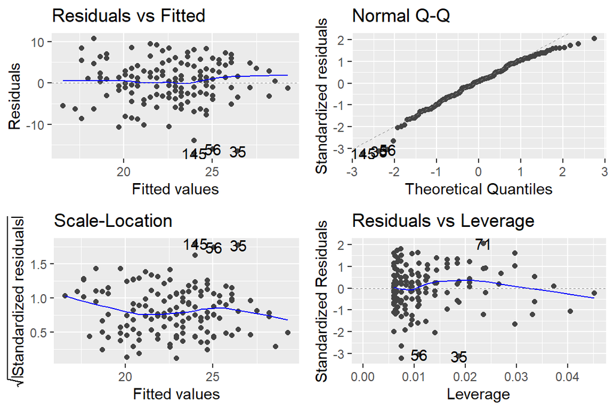

```r
library(ggfortify)
autoplot(my_model2)
```

# Assignment 3

## Data wrangling

I did the data wrangling and the R script is found here: https://github.com/emselina/IODS-project/blob/master/create_alc.R

## Data Analysis

The joined data set used in the analysisexercise combines the two student alcohol consumption data sets. The following adjustments have been made:

The variables not used for joining the two data have been combined by averaging (including the grade variables) ‘alc_use’ is the average of ‘Dalc’ and ‘Walc’ ‘high_use’ is TRUE if ‘alc_use’ is higher than 2 and FALSE otherwise

*2.*

```r
#alc <- read.table("https://raw.githubusercontent.com/KimmoVehkalahti/Helsinki-Open-Data-Science/master/datasets/alc.csv", sep=",", header=TRUE)

alc <- read.csv("data/alc.csv", sep=",", header=TRUE)
colnames(alc)
```

```
##  [1] "school"     "sex"        "age"        "address"    "famsize"
##  [6] "Pstatus"    "Medu"       "Fedu"       "Mjob"       "Fjob"
## [11] "reason"     "guardian"   "traveltime" "studytime"  "schoolsup"
## [16] "famsup"     "activities" "nursery"    "higher"     "internet"
## [21] "romantic"   "famrel"     "freetime"   "goout"      "Dalc"
## [26] "Walc"       "health"     "failures"   "paid"       "absences"
## [31] "G1"         "G2"         "G3"         "alc_use"    "high_use"
```

```r
dim(alc)
```

```
## [1] 370  35
```

```r
str(alc)
```

```
## 'data.frame':    370 obs. of  35 variables:
##  $ school    : chr  "GP" "GP" "GP" "GP" ...
##  $ sex       : chr  "F" "F" "F" "F" ...
##  $ age       : int  18 17 15 15 16 16 16 17 15 15 ...
##  $ address   : chr  "U" "U" "U" "U" ...
##  $ famsize   : chr  "GT3" "GT3" "LE3" "GT3" ...
##  $ Pstatus   : chr  "A" "T" "T" "T" ...
##  $ Medu      : int  4 1 1 4 3 4 2 4 3 3 ...
##  $ Fedu      : int  4 1 1 2 3 3 2 4 2 4 ...
##  $ Mjob      : chr  "at_home" "at_home" "at_home" "health" ...
##  $ Fjob      : chr  "teacher" "other" "other" "services" ...
##  $ reason    : chr  "course" "course" "other" "home" ...
##  $ guardian  : chr  "mother" "father" "mother" "mother" ...
##  $ traveltime: int  2 1 1 1 1 1 1 2 1 1 ...
##  $ studytime : int  2 2 2 3 2 2 2 2 2 2 ...
```

[output cut: 21 more lines]

This dataset is combined from the two student alcohol consumption data sets. The data attributes include student grades, demographic, social and school related features) and it was collected by using school reports and questionnaires. Two datasets are provided regarding the performance in two distinct subjects: Mathematics (mat) and Portuguese language (por). We only kept the students who answered the questionnaire in both math and Portuguese classes. The dataset has 370 observations and 35 variables, including character variables, numeric variables, logical variable and integer variables. Duplicated’ answers from same student were combined in the dataset.

*3. The purpose of your analysis is to study the relationships between high/low alcohol consumption and some of the other variables in the data. To do this, choose 4 interesting variables in the data and for each of them, present your personal hypothesis about their relationships with alcohol consumption. (0-1 point)*

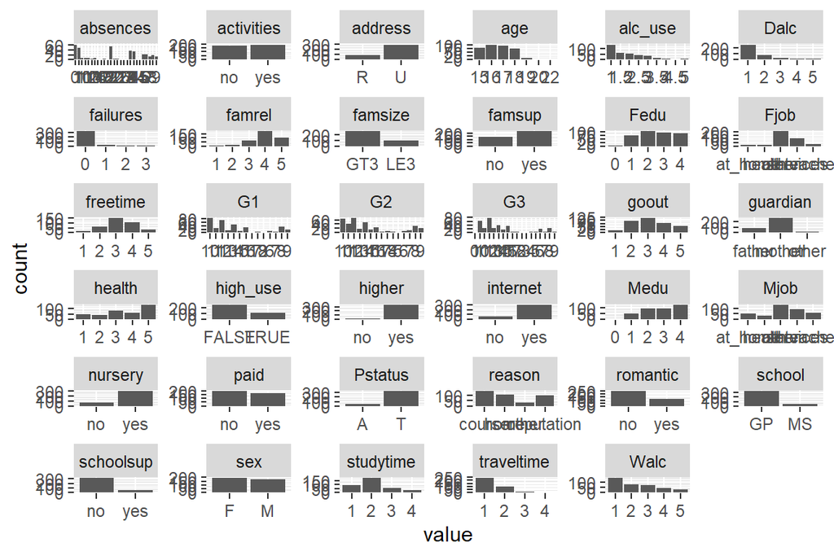

```r
library(tidyr); library(dplyr); library(ggplot2)
gather(alc) %>% ggplot(aes(value)) + facet_wrap("key", scales = "free") + geom_bar()
```

From the dataset I chose the variables `sex`, `failures`, `absences` and `goout` and final grade (`G3`). My hypothesis is that alcohol consumption is higher in men and there is statistically significant correlation between failures (number of past class failures), absences (number of school absences), going out with friends (goot) and final grade (G3) with alcohol consumption. For example the lower the final grade the more alcohol consumption and if you go out more with your friends the alcohol consumption is higher. I hypothise also that if you have more class failurres and absences from school the alcohol consumption is higher.

*4. Numerically and graphically explore the distributions of your chosen variables and their relationships with alcohol consumption (use for example cross-tabulations, bar plots and box plots). Comment on your findings and compare the results of your exploration to your previously stated hypotheses. (0-5 points)*

```r
alc %>% group_by(sex, high_use) %>% summarise(count = n(), mean_grade = (mean(G3)), class_failures = failures, absences = absences, going_out = goout)
```

```
## # A tibble: 370 × 7
## # Groups:   sex, high_use [4]
##    sex   high_use count mean_grade class_failures absences going_out
##    <chr> <lgl>    <int>      <dbl>          <int>    <int>     <int>
##  1 F     FALSE      154       11.4              0        5         4
##  2 F     FALSE      154       11.4              0        3         3
##  3 F     FALSE      154       11.4              0        1         2
##  4 F     FALSE      154       11.4              0        2         2
##  5 F     FALSE      154       11.4              0        4         4
##  6 F     FALSE      154       11.4              0        1         3
##  7 F     FALSE      154       11.4              0        2         2
##  8 F     FALSE      154       11.4              0        5         4
##  9 F     FALSE      154       11.4              0        8         3
## 10 F     FALSE      154       11.4              0        3         2
## # … with 360 more rows
```

Sex, grades and alcohol consumption

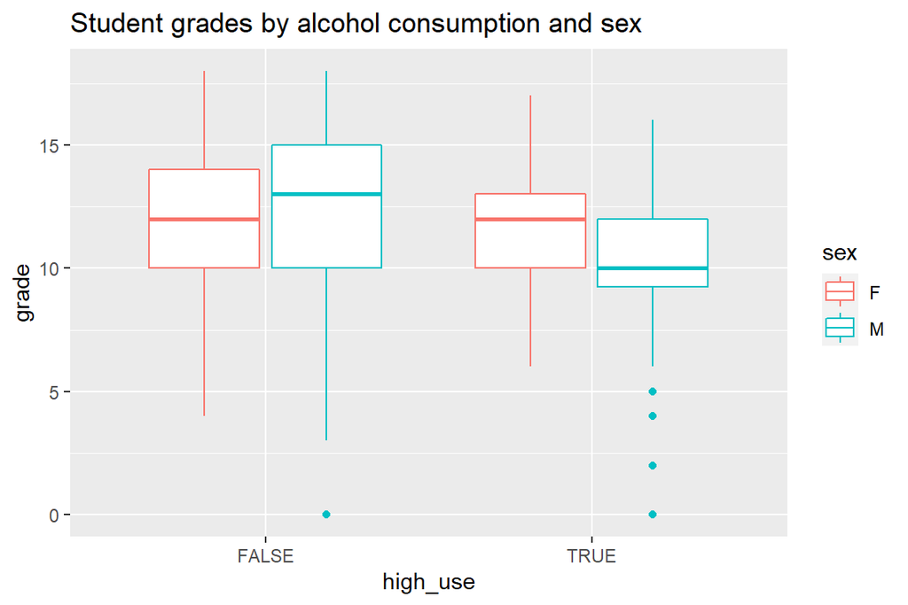

```r
# initialize a plot of high_use and G3
g1 <- ggplot(alc, aes(x = high_use, y = G3, col=sex))

# define the plot as a boxplot and draw it
g1 + geom_boxplot() + ylab("grade") + ggtitle("Student grades by alcohol consumption and sex")
```

Sex, absences and alcohol consumption

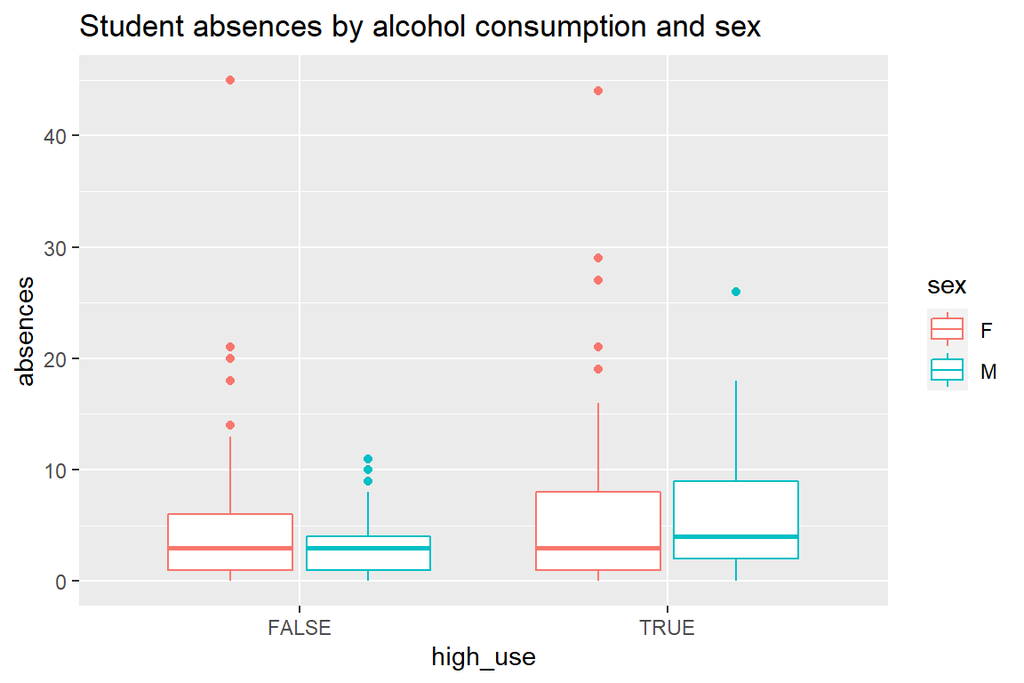

```r
# initialize a plot of high_use and absences
g2 <- ggplot(alc, aes(x = high_use, y = absences, col=sex))

# define the plot as a box plot and draw it
g2 + geom_boxplot() + ylab("absences") + ggtitle("Student absences by alcohol consumption and sex")
```

Sex, going out with friends and alcohol consumption

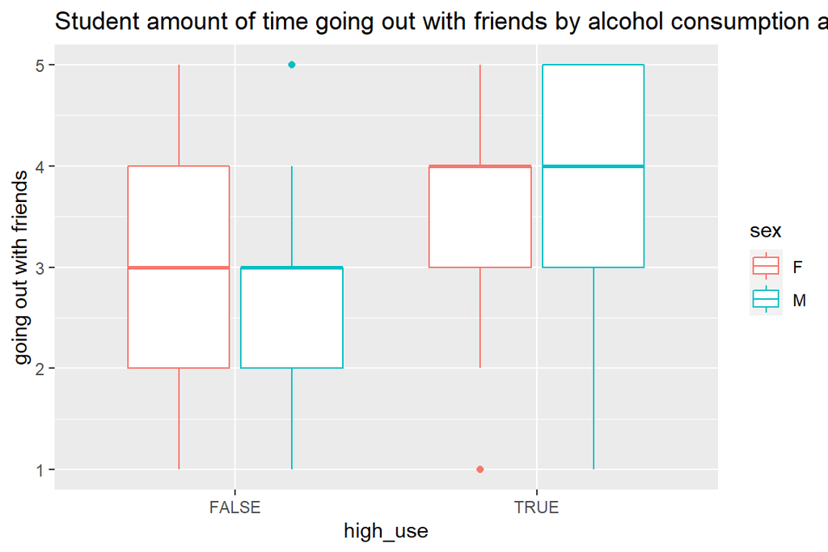

```r
# initialize a plot of high_use and absences
g3 <- ggplot(alc, aes(x = high_use, y = goout, col=sex))

# define the plot as a box plot and draw it
g3 + geom_boxplot() + ylab("going out with friends") + ggtitle("Student amount of time going out with friends by alcohol consumption and sex")
```

Male students with lower final grade from the course had higher alcohol consumption. In females same kind of correlation was not seen.

In students with higher number of school absences the alcohol consumption was higher only in men.

The alcohol consumption was higher in men and women that went out more with their friends. There were not much variation between men and women and alcohol consumption increased in both groups when the time spent with friends increased.

The hypothesis was right that school absences and lower final grade had impact on alcohol consumption and that it was seen in male group. Also time spent going out with friends had correlation with alcohol consumption but that was seen also in women so my hypothesis that men would have higher alchohol consumption was not true in with this variable.

*5. Use logistic regression to statistically explore the relationship between your chosen variables and the binary high/low alcohol consumption variable as the target variable. Present and interpret a summary of the fitted model. Present and interpret the coefficients of the model as odds ratios and provide confidence intervals for them. Interpret the results and compare them to your previously stated hypothesis. Hint: If your model includes factor variables see for example the RHDS book or the first answer of this stackexchange thread on how R treats and how you should interpret these variables in the model output (or use some other resource to study this). (0-5 points)*

```r
# find the model with glm()
m <- glm(high_use ~ failures + absences + goout + sex, data = alc, family = "binomial")

# print out a summary of the model
m %>%
  summary()
```

```
##
## Call:
## glm(formula = high_use ~ failures + absences + goout + sex, family = "binomial",
##     data = alc)
##
## Deviance Residuals:
##     Min       1Q   Median       3Q      Max
## -2.1521  -0.7929  -0.5317   0.7412   2.3706
##
## Coefficients:
##             Estimate Std. Error z value Pr(>|z|)
## (Intercept) -4.14389    0.47881  -8.654  < 2e-16 ***
## failures     0.48932    0.23073   2.121 0.033938 *
## absences     0.08246    0.02266   3.639 0.000274 ***
## goout        0.69801    0.12093   5.772 7.83e-09 ***
## sexM         0.97989    0.26156   3.746 0.000179 ***
## ---
## Signif. codes:  0 '***' 0.001 '**' 0.01 '*' 0.05 '.' 0.1 ' ' 1
##
## (Dispersion parameter for binomial family taken to be 1)
##
##     Null deviance: 452.04  on 369  degrees of freedom
## Residual deviance: 369.50  on 365  degrees of freedom
## AIC: 379.5
##
## Number of Fisher Scoring iterations: 4
```

```r
# print out the coefficients of the model

m %>%
coef()
```

```
## (Intercept)    failures    absences       goout        sexM
## -4.14389330  0.48932427  0.08245946  0.69801208  0.97988506
```

The p-value of the variables absences, goout and sexM (males) had p-value lower than 0.001 so these variables had significant relationship with the target variable high/low alcohol consumption. The variable failures had p-value lower than 0.05 but higher than 0.01 so there was some correlation but it was not as significant as with the other variables.

```r
# compute odds ratios (OR)
OR <- coef(m) %>% exp

# compute confidence intervals (CI)
CI <- confint(m)
# print out the odds ratios with their confidence intervals
cbind(OR, CI)
```

```
##                     OR       2.5 %     97.5 %
## (Intercept) 0.01586098 -5.12422446 -3.2428932
## failures    1.63121360  0.04208372  0.9518235
## absences    1.08595465  0.03922013  0.1293995
## goout       2.00975350  0.46657743  0.9418090
## sexM        2.66415000  0.47316089  1.5009085
```

*6. Using the variables which, according to your logistic regression model, had a statistical relationship with high/low alcohol consumption, explore the predictive power of you model. Provide a 2x2 cross tabulation of predictions versus the actual values and optionally display a graphic visualizing both the actual values and the predictions. Compute the total proportion of inaccurately classified individuals (= the training error) and comment on all the results. Compare the performance of the model with performance achieved by some simple guessing strategy. (0-3 points)*

Variables absences, goout and sex had the highest statistical relationship with high/low alcohol consumption so I included them to the model.

```r
# fit the model
m <- glm(high_use ~ absences + goout + sex, data = alc, family = "binomial")

# predict() the probability of high_use
probabilities <- predict(m, type = "response")

library(dplyr)
# add the predicted probabilities to 'alc'
alc <- mutate(alc, probability = probabilities)

# use the probabilities to make a prediction of high_use
alc <- mutate(alc, prediction = probabilities > 0.5)


# see the last ten original classes, predicted probabilities, and class predictions
select(alc, absences, sex, goout, high_use, probability, prediction) %>% tail(10)
```

```
##     absences sex goout high_use probability prediction
## 361        3   M     3    FALSE  0.32716276      FALSE
## 362        0   M     2    FALSE  0.15403200      FALSE
## 363        7   M     3     TRUE  0.40566343      FALSE
## 364        1   F     3    FALSE  0.12866204      FALSE
## 365        6   F     3    FALSE  0.18408147      FALSE
## 366        2   F     2    FALSE  0.07202493      FALSE
## 367        2   F     4    FALSE  0.24971608      FALSE
## 368        3   F     1    FALSE  0.03919794      FALSE
## 369        4   M     5     TRUE  0.69415157       TRUE
## 370        2   M     1     TRUE  0.09434569      FALSE
```

```r
# tabulate the target variable versus the predictions
table(high_use = alc$high_use, prediction = alc$prediction)
```

```
##         prediction
## high_use FALSE TRUE
##    FALSE   242   17
##    TRUE     61   50
```

graphic visualization:

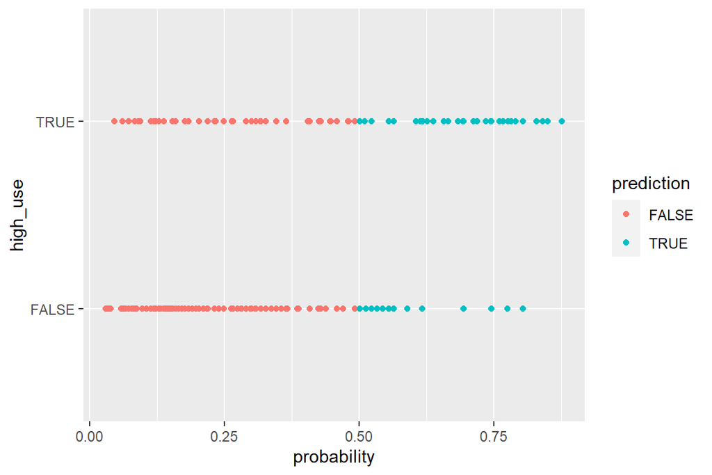

```r
# initialize a plot of 'high_use' versus 'probability' in 'alc'
g <- ggplot(alc, aes(x = probability, y = high_use, col = prediction))

# define the geom as points and draw the plot
g + geom_point()
```

```r
# tabulate the target variable versus the predictions
table(high_use = alc$high_use, prediction = alc$prediction)%>%
  prop.table()%>%
  addmargins()
```

```
##         prediction
## high_use      FALSE       TRUE        Sum
##    FALSE 0.65405405 0.04594595 0.70000000
##    TRUE  0.16486486 0.13513514 0.30000000
##    Sum   0.81891892 0.18108108 1.00000000
```

training error

```r
# define a loss function (mean prediction error)
loss_func <- function(class, prob) {
  n_wrong <- abs(class - prob) > 0.5
  mean(n_wrong)
}

# call loss_func to compute the average number of wrong predictions in the (training) data
loss_func(class = alc$high_use, prob = 0)
```

```
## [1] 0.3
```

```r
# call loss_func to compute the average number of wrong predictions in the (training) data
loss_func(class = alc$high_use, prob = 1)
```

```
## [1] 0.7
```

```r
# call loss_func to compute the average number of wrong predictions in the (training) data
loss_func(class = alc$high_use, prob = alc$probability)
```

```
## [1] 0.2108108
```

The training error says that the average number of wrong predictions of the model is 0.21.

*7. Bonus: Perform 10-fold cross-validation on your model. Does your model have better test set performance (smaller prediction error using 10-fold cross-validation) compared to the model introduced in the Exercise Set (which had about 0.26 error). Could you find such a model? (0-2 points to compensate any loss of points from the above exercises)*

```r
# define a loss function (average prediction error)
loss_func <- function(class, prob) {
  n_wrong <- abs(class - prob) > 0.5
  mean(n_wrong)
}

# compute the average number of wrong predictions in the (training) data

loss_func(class = alc$high_use, prob = alc$probability)
```

```
## [1] 0.2108108
```

```r
# K-fold cross-validation
library(boot)
cv <- cv.glm(data = alc, cost = loss_func, glmfit = m, K = nrow(alc))

# average number of wrong predictions in the cross validation
cv$delta[1]
```

```
## [1] 0.2189189
```

```r
# 10-fold cross-validation
library(boot)
cv <- cv.glm(data = alc, cost = loss_func, glmfit = m, K=10)

# average number of wrong predictions in the 10-fold cross validation
cv$delta[1]
```

```
## [1] 0.2135135
```

My model has a 10-fold cross validation gave prediction error of about 0.21 so that is smaller than the error compared to the model introduced in the Exercise Set.

(more chapters to be added similarly as we proceed with the course!)